# Neural Network Recap

## Outline

- 5 Typical steps in approaching a deep learning problem
- Building blocks of a neural network
  - input_data
  - Sequential / functional model: a linear stack of layers.
  - Layers
  - Compiled model: optimizer, loss, metrics
- Demystifying the jargon
- Hands on: Building and training a neural network

## 5 Typical steps in approaching a deep learning problem

1. Find out the dimensions and shapes of the training data (X) and training labels (y)

- This will inform how we specify our input and output layers
- Reshape the training data if necessary

2. Specify the architecture of your neural network model (Construction phase)

- Specify layers and add layers to model
- Specify hyperparameters
  - number of hidden layers
  - number of neurons
  - number of epochs
  - optimizer
  - learning rate
  - activation function (e.g. sigmoid, softmax, tanh)
  - etc.

3. Train model (Execution phase)

4. Optimize hyperparameters

5. Use model

**Given enough data on X and y, neural networks are remarkable good at figuring out functions/models that fit the data**

## Building blocks of a neural network

### 1. Model and layers

- The Sequential model is a linear stack of layers.
- You can create a Sequential model by passing a list of layer instances to the constructor:

```python
from keras.models import Sequential
from keras.layers import Dense, Activation

model = Sequential([
    Dense(32, input_shape=(784,)),
    Activation('relu'),
    Dense(10),
    Activation('softmax'),
])
```

You can also simply add layers via the .add() method:

```python
model = Sequential()
model.add(Dense(32, input_dim=784))
model.add(Activation('relu'))
```

### 2. Layers

Layers take in the following arguments:

- units: Number of neurons in a layer (also the dimensionality of the output space).
- activation: Activation function to use (see activations). If you don't specify anything, no activation is applied (ie. "linear" activation: a(x) = x).
- `input_shape` (only for **input layer**): The input layer needs to know what input shape it should expect, we need to specify the `input_shape` argument for just the first layer (The following layers do automatic shape inference).

### 3. Compilation

```python
model.compile(optimizer='rmsprop',
              loss='categorical_crossentropy',
              metrics=['accuracy'])
```

`model.compile()` lets us to specify the hyperparameters of the learning process:

- An **optimizer**. This could be the string identifier of an existing optimizer (such as rmsprop or adagrad), or an instance of the Optimizer class.
- A **loss function**. This is the objective that the model will try to minimize. It can be the string identifier of an existing loss function (such as categorical_crossentropy or mse), or it can be an objective function
- A **list of metrics**. For any classification problem you will want to set this to metrics=['accuracy']. A metric could be the string identifier of an existing metric or a custom metric function.

### 4. Training

Keras models are trained on Numpy arrays of input data and labels. It can take the following parameters:

- **training data**: X
- **training labels**: y
- **number of epochs**: an integer
- **batch_size**: an integer
- (optional) **validation_data**: a tuple (x_val, y_val)

```python
model.fit(data, labels, epochs=10, batch_size=32)
```

## Demystifying the jargons

### Jargons

- Neural network:
  - A neural network is essentially a function, with input values and output values
  - It also has hundreds of thousands of parameters (W and b)
- Parameters
  - Weights
  - biases

[figure not shown]

- Hyperparameters
  - learning rate
  - activation function (e.g. sigmoid, softmax, tanh)
  - number of hidden layers
  - number of neurons
  - number of epochs
  - optimizer
- gradient descent
  - gradient (i.e. slope of cost function)
- forward propagation: compute output of the function
- backward propagation: compute derivative of the function
- vector: a matrix
  - e.g. v == (5, 0) == [5 0]
  - e.g. u == (5, 2, 0) == [5 2 0]
  - Vectorized implementations can be hundreds of times faster than a for-loop implementation.
  - It’s fast because matrix multiplications can take advantage of parallelism in CPUs and GPUs

## Building and training a neural network

### 1. Import dependencies

```python
from __future__ import print_function
import keras
from keras.datasets import mnist
from keras.models import Sequential
from keras.layers import Dense, Dropout, Flatten
from keras.layers import Conv2D, MaxPooling2D
from keras import backend as K

import matplotlib.pyplot as plt
%matplotlib inline
```

### 2. Load data

```python
from keras.datasets import mnist
(x_train, y_train), (x_test, y_test) = mnist.load_data()
```

### 3. Explore / inspect / reshape data

[output not shown]

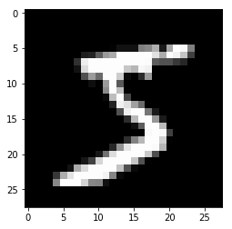

```python
# Explore data
print(x_train.shape)
plt.imshow(x_train[0].reshape((28, 28)), cmap='gray')
```

```python
# Reshape data
x_train = x_train.reshape(60000, 784)
x_test = x_test.reshape(10000, 784)

# Convert to float so that we can divide it by 255 and get a float
x_train = x_train.astype('float32')
x_test = x_test.astype('float32')

# Normalize data to range from 0 to 1
x_train /= 255
x_test /= 255
print('x_train shape:', x_train.shape)

# convert class vectors to binary class matrices
num_classes = 10
y_train = keras.utils.to_categorical(y_train, num_classes)
y_test = keras.utils.to_categorical(y_test, num_classes)
```

```
x_train shape: (60000, 784)
```

### 4. Building the model

```python
# 1. Instantiate model
model = Sequential()

# 2. Add layers
model.add(Dense(512, activation='relu', input_shape=(784,)))
model.add(Dense(512, activation='relu'))
model.add(Dense(10, activation='softmax'))

# 3. Compile model. Specify: optimizer, loss and metrics
model.compile(optimizer='adam', loss='categorical_crossentropy', metrics=['accuracy'])
```

```python
# 4. Inspect architecture of model
model.summary()
```

```
_________________________________________________________________
Layer (type)                 Output Shape              Param #
=================================================================
dense_4 (Dense)              (None, 512)               401920
_________________________________________________________________
dense_5 (Dense)              (None, 512)               262656
_________________________________________________________________
dense_6 (Dense)              (None, 10)                5130
=================================================================
Total params: 669,706
Trainable params: 669,706
Non-trainable params: 0
_________________________________________________________________
```

### 5. Train the model

```python
history = model.fit(x_train, y_train,
                    batch_size=10,
                    epochs=2,
                    verbose=1,
                    validation_data=(x_test, y_test))
```

```
Train on 60000 samples, validate on 10000 samples
```

# Convolution Neural Network

### 2. Load data

```python
(x_train, y_train), (x_test, y_test) = mnist.load_data()
```

### 3. Explore / inspect / reshape data

```python
# input image dimensions
img_rows, img_cols = 28, 28

if K.image_data_format() == 'channels_first':
    x_train = x_train.reshape(x_train.shape[0], 1, img_rows, img_cols)
    x_test = x_test.reshape(x_test.shape[0], 1, img_rows, img_cols)
    input_shape = (1, img_rows, img_cols)
else:
    x_train = x_train.reshape(x_train.shape[0], img_rows, img_cols, 1)
    x_test = x_test.reshape(x_test.shape[0], img_rows, img_cols, 1)
    input_shape = (img_rows, img_cols, 1)

x_train = x_train.astype('float32')
x_test = x_test.astype('float32')
x_train /= 255
x_test /= 255
print('x_train shape:', x_train.shape)

# convert class vectors to binary class matrices
y_train = keras.utils.to_categorical(y_train, 10)
y_test = keras.utils.to_categorical(y_test, 10)
```

```
x_train shape: (60000, 28, 28, 1)
```

### 4. Build model

```python
# 1. Instantiate model
model = Sequential()

# 2. Add layers
model.add(Conv2D(32, kernel_size=(3, 3),
                 activation='relu',
                 input_shape=(28, 28, 1)))
model.add(Conv2D(64, (3, 3), activation='relu'))
model.add(MaxPooling2D(pool_size=(2, 2)))
model.add(Flatten())
model.add(Dense(128, activation='relu'))
model.add(Dense(10, activation='softmax'))

# 3. Compile the model
model.compile(loss='categorical_crossentropy',
              optimizer='adam',
              metrics=['accuracy'])
```

### 5. Train model

```python
model.fit(x_train, y_train,
          batch_size=64,
          epochs=2,
          verbose=1,
          validation_data=(x_test, y_test))
```

```
Train on 60000 samples, validate on 10000 samples
```

```
<keras.callbacks.History at 0x134fa4350>
```